# Data Science and Data Analytics

## Working with dates

So let’s try to use this to convert our dates (which are now just `character` objects) to actual dates that R understands using `as.Date`:

```r
bday_anna <- as.Date("1999-12-01", "%Y-%m-%d")
bday_jakob <- as.Date("16.4.98", "%d.%m.%y")
bday_lisa <- as.Date("7/June/1995", "%d/%B/%Y")
bday_anna
```

```
[1] "1999-12-01"
```

```r
bday_jakob
```

```
[1] "1998-04-16"
```

```r
bday_lisa
```

```
[1] "1995-06-07"
```

Now, we can add these dates as a column to our `data.frame`

```r
df$bday <- c(bday_anna, bday_jakob, bday_lisa)
df
```

```
  heights names educ sex       bday
1     176  Anna  BSc   f 1999-12-01
2     187 Jakob   MA   m 1998-04-16
3     156  Lisa  PhD   f 1995-06-07
```

## Working with dates

Dates are stored in R as the number of days since [Unix time](https://en.wikipedia.org/wiki/Unix_time), which is the 1st January, 1970. Hence, date vectors are simply `double` vectors of class `Date`.

```r
typeof(df$bday)
```

```
[1] "double"
```

```r
as.double(df$bday)
```

```
[1] 10926 10332  9288
```

```r
class(df$bday)
```

```
[1] "Date"
```

With this underlying representation, we can do maths on dates:

```r
df$bday
```

```
[1] "1999-12-01" "1998-04-16" "1995-06-07"
```

```r
df$bday + 30
```

```
[1] "1999-12-31" "1998-05-16" "1995-07-07"
```

```r
df$bday[2] - df$bday[1]
```

```
Time difference of -594 days
```

## Working with dates

Note that these operations cannot be performed on the original character strings representing the birthdays:

```r
"1999-12-01" + 10
```

```
Error in "1999-12-01" + 10: nicht-numerisches Argument für binären Operator
```

To extract individual parts of a date (like year, month, day, weekday, etc.), we can use the `format` function in conjunction with the format strings we saw before for date creation:

```r
format(df$bday, "%Y") # extract birth year
```

```
[1] "1999" "1998" "1995"
```

```r
format(df$bday, "%B") # extract birth month
```

```
[1] "December" "April"    "June"
```

```r
format(df$bday, "%A") # extract week day of birth date
```

```
[1] "Wednesday" "Thursday"  "Wednesday"
```

## Working with dates

[figure not shown]

# Programming basics

## R programming for Data Science

- By coding in R, we can efficiently perform exploratory data analysis, build machine learning pipelines, and prepare beautiful plots to communicate results effectively using data visualization tools.
- However, R is not just a data analysis environment but a **programming language**.
- The goal of this is course is not to teach advanced R programming, but in order to facilitate our lives as data scientists, we do need access to certain core programming principles like **conditionals**, **loops** and **functionals**.
- So let’s dive right in!

## Conditionals

**Conditionals** are one of the basic features of programming. They are used for what is called **control flow**. The most common conditional expression is the `if-else` statement. It’s best illustrated with an example:

```r
a <- 0
if (a != 0) {
  print(1/a)
} else{
  print("Can't divide by zero!")
}
```

```
[1] "Can't divide by zero!"
```

The condition `a != 0` was evaluated to be `FALSE` (since `a` was assigned 0). So, the conditional went to the `else` statement and printed “Can’t divide by zero!” to the console as we told it to. By contrast:

```r
a <- 4
if (a != 0) {
  print(1/a)
} else{
  print("Can't divide by zero!")
}
```

```
[1] 0.25
```

## Conditionals

Let’s incorporate conditionals into our `quadratic_solver` function from before. Remember that a quadratic equation has no real solutions if the **discriminant** $D$ is negative (because of the root in the “midnight” formula):

$$D = b^2 - 4ac$$

So far, when this is case, our function produces `NaN`s and a warning:

```r
quadratic_solver(2, 2, 2)
```

```
Warning in sqrt(b^2 - 4 * a * c): NaNs wurden erzeugt
Warning in sqrt(b^2 - 4 * a * c): NaNs wurden erzeugt
```

```
[1] NaN NaN
```

Let’s fix this by:

- Returning no solutions / NA if $D < 0$.
- Returning one solution if $D = 0$.
- Returning two solutions (as before) if $D > 0$.

## Conditionals

One solution could be the following:

```r
quadratic_solver_new <- function(a, b, c){
  D <- b^2 - 4*a*c
  if(D < 0){
    print("Discriminant is negative, no real solutions!")
    return(NA)
  } else if(D > 0) {
    print("Discriminant is positive, two real solutions!")
    sol_1 <- (-b + sqrt(D))/(2*a)
    sol_2 <- (-b - sqrt(D))/(2*a)
    return(c(sol_1, sol_2))
  } else {
    print("Discriminant is zero, one real solution!")
    sol <- -b/(2*a)
    return(sol)
  }
}
```

```r
quadratic_solver_new(2, 2, 2)
```

```
[1] "Discriminant is negative, no real solutions!"
```

```
[1] NA
```

```r
quadratic_solver_new(3, -5, 1)
```

```
[1] "Discriminant is positive, two real solutions!"
```

```
[1] 1.4342585 0.2324081
```

```r
quadratic_solver_new(1, 2, 1)
```

```
[1] "Discriminant is zero, one real solution!"
```

```
[1] -1
```

## Conditionals

`if-else` statements like the ones we saw only work on a single logical. For a **vectorized** version, there is the very useful `ifelse` function:

```r
a <- c(0, 2, 4, 6, 0, 8)
ifelse(a != 0, 1/a, NA)
```

```
[1]        NA 0.5000000 0.2500000 0.1666667        NA 0.1250000
```

This function takes three arguments: a logical and two possible answers. If the logical is TRUE, the value in the second argument is returned and if FALSE, the value in the third argument is returned. When operating on vectors, `ifelse` takes the corresponding **elements** of the second or third argument.

Here’ another example:

```r
x <- 1:10
ifelse(x %% 2 == 0, "even", "odd")
```

```
 [1] "odd"  "even" "odd"  "even" "odd"  "even" "odd"  "even" "odd"  "even"
```

Note: `x %% 2` gives the remainder when dividing x by 2.

## For-loops

In general, **loops** control flow structures that enable the repeated execution of a code block as long as a specified condition is met. This saves a lot of manual work and code duplication. We will discuss two types of loops: `for` loops and `while` loops.

`for` loops are used to **iterate** over items in a vector. The logic is “for every item in this vector, do the following”. This logic is implemented in the following basic form:

```r
for(item in vector) {
  perform_action
}
```

Following this notation, we can refer to the element of the `vector` in the current loop cycle with the name of `item`. In the first cycle, it will be the first element of the vector, in the second, it will be the second, and so on…

## For-loops

Let’s see an example of a `for` loop that prints both solutions to the quadratic equation from before in a nice format:

```r
solutions <- quadratic_solver_new(3, -5, 1)
```

```
[1] "Discriminant is positive, two real solutions!"
```

```r
n <- length(solutions)

for(i in 1:n){
  print(paste0("Solution ", i, ": ", round(solutions[i], 3)))
}
```

```
[1] "Solution 1: 1.434"
[1] "Solution 2: 0.232"
```

Note that we do not have to loop through an integer vector, we can loop through any atomic vector or list. For example, we could loop through all the elements of the list `l1` from earlier and print it to the console only if it is a numeric vector:

```r
for(el in l1){
  if(is.numeric(el)){
    print(el)
  }
}
```

```
[1] 1 2 3
[1] 2.3 5.9
```

## While-loops

Another type of loop is a `while` loop. It repeats a specified action as long as a certain condition is met. It has the following basic form:

```r
while(condition){
  perform_action
}
```

Note that `for` and `while` loops are interchangeable in **every circumstance**, i.e. every `for` loop can be implemented as a `while` loop and vice versa. Usually, the choice between the two is a question of code readability and efficiency considerations. Compare the following two examples:

```r
i <- 1L
while(i <= 3L){
  print(i)
  i <- i + 1L
}
```

```
[1] 1
[1] 2
[1] 3
```

Note that the last step in the loop is crucial. Otherwise we loop infinitely!

```r
for(i in 1:3){
  print(i)
}
```

```
[1] 1
[1] 2
[1] 3
```

## Functionals

In R, a very commonly used alternative to loops is the use of **functionals**. Functionals are functions that take another function as an input and returns a vector as output. Common functionals we will have a look at are `lapply`, and `apply`. Let’s start with `lapply`.

`lapply` requires as arguments an atomic vector or a list and a function that it should apply to each element of that atomic vector or list. Let’s say we wanted to sort each vector in a list of vectors. We could do:

```r
l2 <- list(sample(1:10), sample(1:20))
l2
```

```
[[1]]
 [1] 10  9  5  4  7  1  3  6  8  2

[[2]]
 [1]  5 14 20  2 17  8  1 16 18 15  7 11 12  4 19 10  3 13  9  6
```

```r
lapply(l2, sort)
```

```
[[1]]
 [1]  1  2  3  4  5  6  7  8  9 10

[[2]]
 [1]  1  2  3  4  5  6  7  8  9 10 11 12 13 14 15 16 17 18 19 20
```

## Functionals

In fact, we can pass named arguments that we would usually pass to the function to be applied directly to `lapply` instead:

```r
lapply(l2, sort, decreasing = TRUE)
```

```
[[1]]
 [1] 10  9  8  7  6  5  4  3  2  1

[[2]]
 [1] 20 19 18 17 16 15 14 13 12 11 10  9  8  7  6  5  4  3  2  1
```

Instead of using `lapply` with a pre-existing (or user-defined) function, we can also create an inline function that exists only for the purpose of that `lapply` call. For example, we might want to square each vector in the list after sorting:

```r
lapply(l2, function(x) sort(x, decreasing = TRUE)^2)
```

```
[[1]]
 [1] 100  81  64  49  36  25  16   9   4   1

[[2]]
 [1] 400 361 324 289 256 225 196 169 144 121 100  81  64  49  36  25  16   9   4
[20]   1
```

Such functions are called **anonymous functions** as they do not have a name.

## Functionals

The **matrix** equivalent of `lapply` is called `apply`. It can apply a given function to every row and / or every column of a matrix. Besides requiring the matrix and the function to be applied, it requires an indication of whether application should happen over **rows** (1) or **columns** (2). Consider the following example to compute the row and column sums of a matrix:

```r
m <- matrix(1:9, 3, 3)
m
```

```
     [,1] [,2] [,3]
[1,]    1    4    7
[2,]    2    5    8
[3,]    3    6    9
```

```r
apply(m, 1, sum)
```

```
[1] 12 15 18
```

```r
apply(m, 2, sum)
```

```
[1]  6 15 24
```

The use of functionals like `lapply` and `apply` is usually preferable over loops because it pre-specifies what should happen with the result (e.g. `lapply` will always hold the results in a list).

# Packages

## Packages

- With the base installation, R comes with a lot of functionality already. However, statisticians and data scientists all over the world constantly come up with new methods and clever code to solve problems.
- To share this code, they create **R packages**: these include fundamental units of reproducible R code, including reusable R functions, the documentation that describes how to use them, and sample data.
- To make these packages available, the creators typically upload them to the **Comprehensive R Archive Network (CRAN)**.
- From there, any R user can download and install these packages and use them for their own workflows.

## Packages

- As of 22nd February 2025, there are 22,100 R packages available for download on [CRAN](https://cran.r-project.org/web/packages/). Each of them has a unique name that we can use to obtain it.
- We will be working only with a select few of them.
- One of them will be **ggplot2**, which is one of the most popular R packages used for data visualization.
- As an R programmer, one typically finds packages that solve a given problem by googling the problem one is encountering. Chances are that someone else has had this problem before…

To install a package, we call the function `install.packages` on the name of the package:

```r
install.packages("ggplot2")
```

This downloads and installs the package on your computer.

## Packages

As with any software, an R package only needs to be **installed** once.

After installation, we need to tell R to make the functions provided by this package available to us in our current R session. For this we call the function `library` on the name of the package:

```r
library(ggplot2)
```

- Now, all data and functions offered by this package can be used.
- A package comes with a [reference manual](https://cran.r-project.org/web/packages/ggplot2/ggplot2.pdf) and often additional documentation in the form of so called package [**vignettes**](https://cran.r-project.org/web/packages/ggplot2/vignettes/ggplot2.html).
- This helps the user understand how to use the functions in the package.
- Additionally, documentation on individual functions is always available through the help of the `?` operator.

## Packages

```r
ggplot(mpg, aes(displ, hwy, colour = class)) +
  geom_point() +
  xlab("Engine Displacement") + ylab("MPG") +
  theme(legend.text = element_text(size=14), axis.text = element_text(size=14), axis.title = element_text(size=14))
```

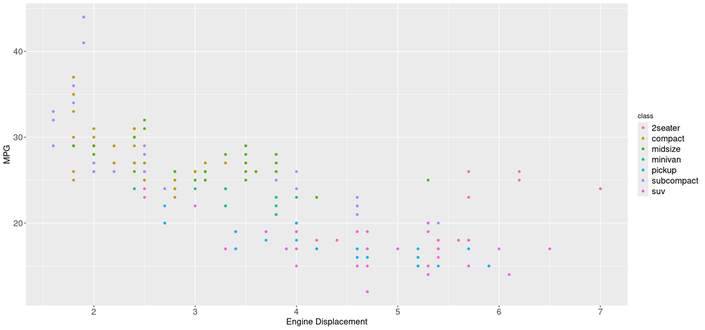